# Employee Attrition Analaysis

# 2. Characteristics and Features of an Employee?

## Analyse Attrition vs Years with current manager

### Analyse Feature Years in Current Role verses the Attrition Rate of the employee. We are able to see that employees working with the same manager for 1-9 years have the higest attrition rate of 15.5%

### YearsWithCurrManager : 96.4%

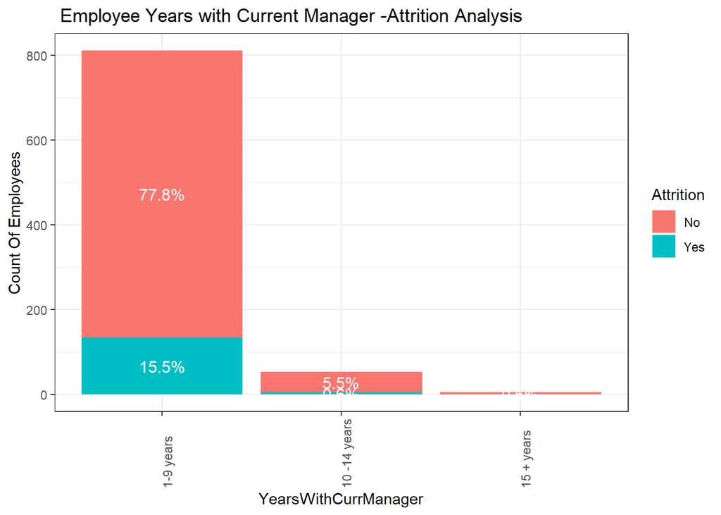

```r
dtCurrentManager <- employeedata%>%
  dplyr::group_by(YearsWithCurrManager,Attrition)%>%
  dplyr::tally()%>%
  dplyr::mutate(percent=n/870)


 p8<-ggplot(data = dtCurrentManager,aes(x= YearsWithCurrManager , y = n,fill = Attrition))+
   geom_bar(stat="identity")+geom_text(aes(label=paste0(sprintf("%1.1f", percent*100),"%")), position=position_stack(vjust=0.5), colour="white", size = 4)+theme(axis.text.x = element_text(angle = 90,hjust =0 ))+ggtitle(" Employee Years with Current Manager -Attrition Analysis")+ylab("Count Of Employees")

 p8
```

## Analyse Attrition vs Years in Current Role

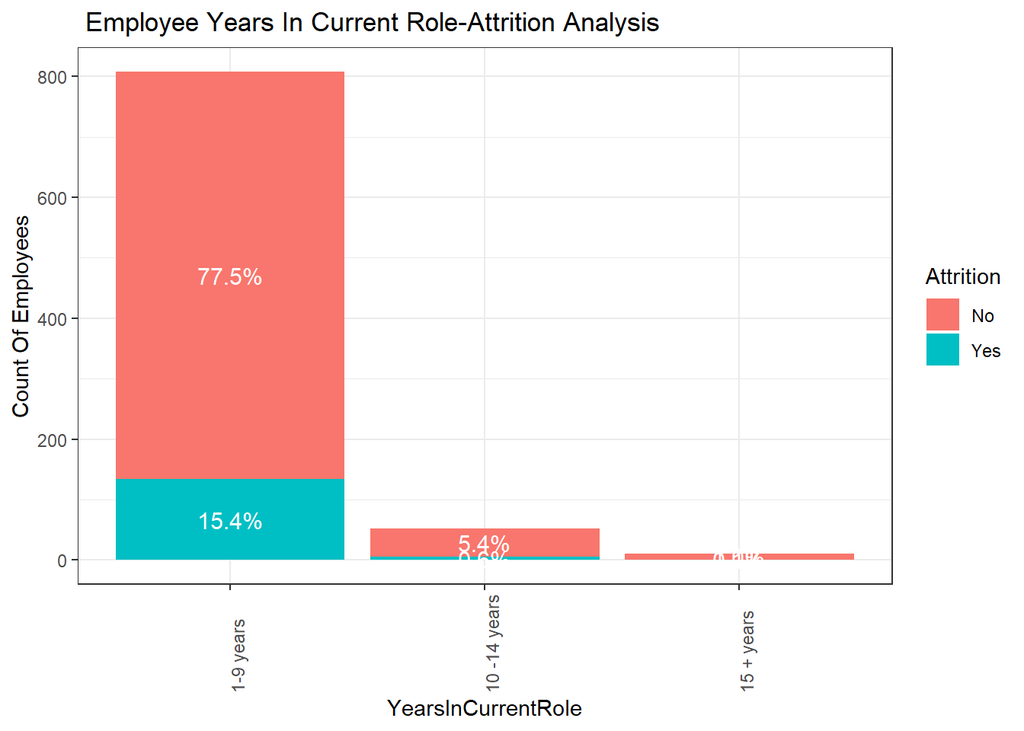

```r
dtCurrentRole <- employeedata%>%
  dplyr::group_by(YearsInCurrentRole,Attrition)%>%
  dplyr::tally()%>%
  dplyr::mutate(percent=n/870)


p9<- ggplot(data = dtCurrentRole,aes(x= YearsInCurrentRole , y = n,fill = Attrition))+
   geom_bar(stat="identity")+geom_text(aes(label=paste0(sprintf("%1.1f", percent*100),"%")), position=position_stack(vjust=0.5), colour="white", size = 4)+theme(axis.text.x = element_text(angle = 90,hjust =0 ))+ggtitle(" Employee Years In Current Role-Attrition Analysis")+ylab("Count Of Employees")

p9
```

## Attrition vs Age of the employee

### 30-39 years : 38.6%

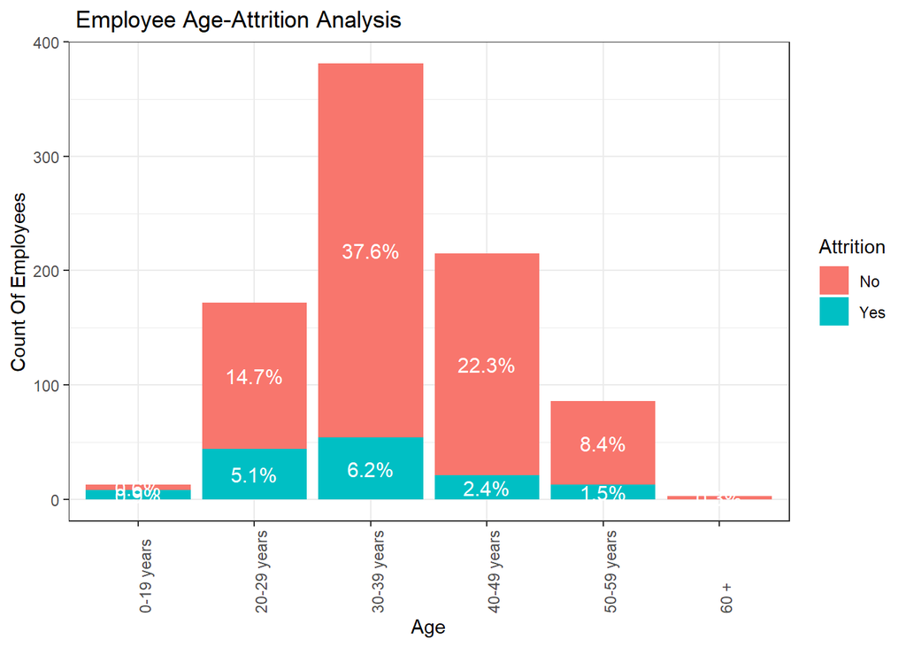

```r
dtAge <- employeedata%>%
  dplyr::group_by(Age,Attrition)%>%
  dplyr::tally()%>%
  dplyr::mutate(percent=n/870)


p10<- ggplot(data = dtAge,aes(x= Age, y = n,fill = Attrition))+
   geom_bar(stat="identity")+geom_text(aes(label=paste0(sprintf("%1.1f", percent*100),"%")), position=position_stack(vjust=0.5), colour="white", size = 4)+theme(axis.text.x = element_text(angle = 90,hjust =0 ))+ggtitle(" Employee Age-Attrition Analysis")+ylab("Count Of Employees")

p10
```

## Employee Attrition vs Gender of the employee

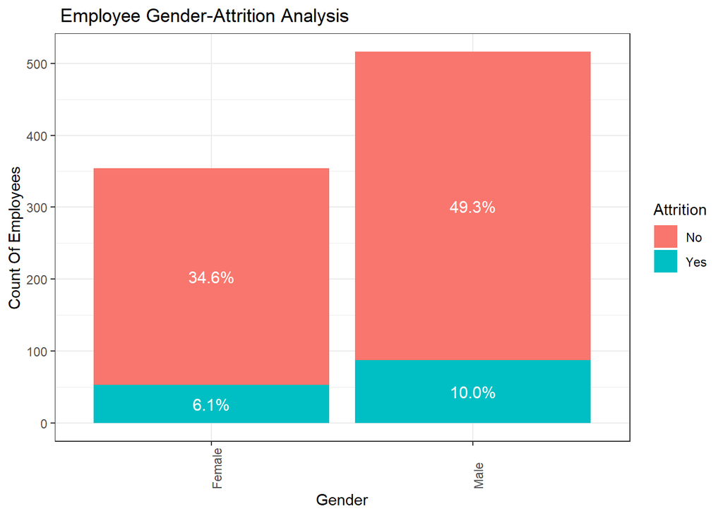

```r
dtGender <- employeedata%>%
  dplyr::group_by(Gender,Attrition)%>%
  dplyr::tally()%>%
  dplyr::mutate(percent=n/870)


 p11<-ggplot(data = dtGender,aes(x=Gender , y = n,fill = Attrition))+ geom_bar(stat="identity")+geom_text(aes(label=paste0(sprintf("%1.1f", percent*100),"%")), position=position_stack(vjust=0.5), colour="white", size = 4)+theme(axis.text.x = element_text(angle = 90,hjust =0 ))+ggtitle(" Employee Gender-Attrition Analysis")+ylab("Count Of Employees")

 p11
```

## Employee Attrition vs Martial Status

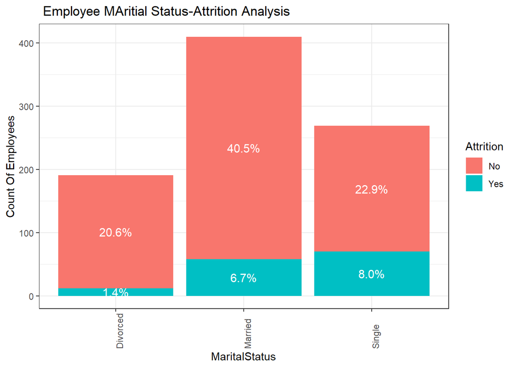

```r
dtMaritial <- employeedata%>%
  dplyr::group_by(MaritalStatus,Attrition)%>%
  dplyr::tally()%>%
  dplyr::mutate(percent=n/870)


 p12<-ggplot(data = dtMaritial,aes(x=MaritalStatus, y = n,fill = Attrition))+ geom_bar(stat="identity")+geom_text(aes(label=paste0(sprintf("%1.1f", percent*100),"%")), position=position_stack(vjust=0.5), colour="white", size = 4)+theme(axis.text.x = element_text(angle = 90,hjust =0 ))+ggtitle(" Employee MAritial Status-Attrition Analysis")+ylab("Count Of Employees")

 p12
```

## Employee Attrition vs Total Working Years

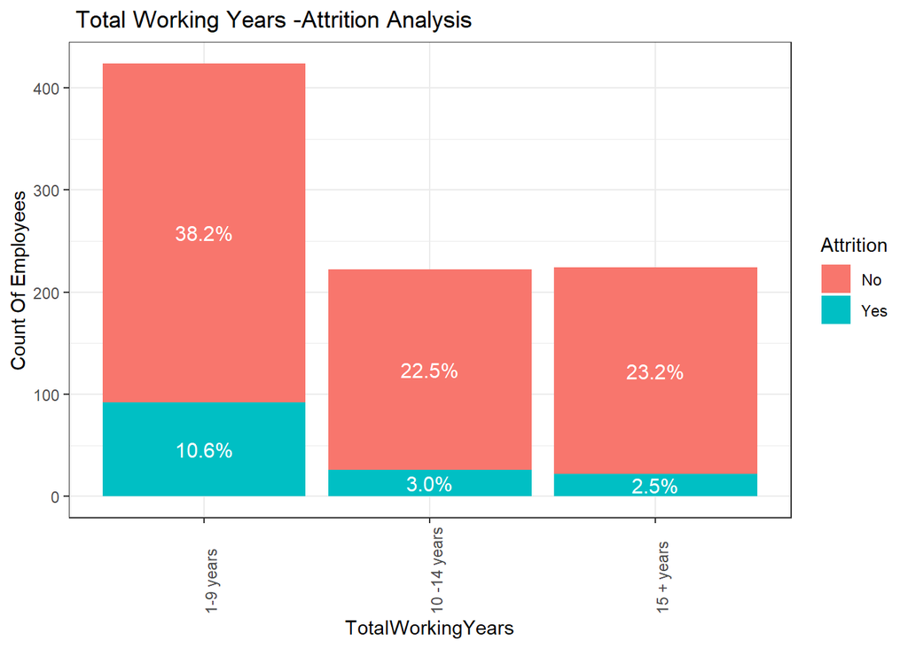

```r
dtWork <- employeedata%>%
  dplyr::group_by(TotalWorkingYears,Attrition)%>%
  dplyr::tally()%>%
  dplyr::mutate(percent=n/870)


 p13<-ggplot(data = dtWork ,aes(x= TotalWorkingYears
, y = n,fill = Attrition))+ geom_bar(stat="identity")+geom_text(aes(label=paste0(sprintf("%1.1f", percent*100),"%")), position=position_stack(vjust=0.5), colour="white", size = 4)+theme(axis.text.x = element_text(angle = 90,hjust =0 ))+ggtitle(" Total Working Years -Attrition Analysis")+ylab("Count Of Employees")

p13
```

## Employee Attrition vs Department

## Most of the employees from the sales department have the highest attrition rate which would be 21.6%

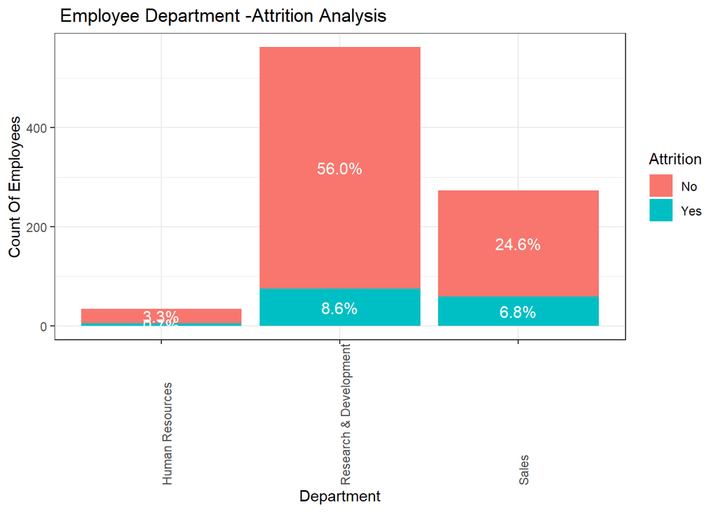

```r
  dtDep <- employeedata%>%
    dplyr::group_by(Department,Attrition)%>%
    dplyr::tally()%>%
    dplyr::mutate(percent=n/870)


  p14<- ggplot(data = dtDep,aes(x= Department, y = n,fill = Attrition))+ geom_bar(stat="identity")+geom_text(aes(label=paste0(sprintf("%1.1f", percent*100),"%")), position=position_stack(vjust=0.5), colour="white", size = 4)+theme(axis.text.x = element_text(angle = 90,hjust =0 ))+ggtitle(" Employee Department -Attrition Analysis")+ylab("Count Of Employees")

  p14
```

## Education vs the Attrition

## Education level of an employee vs Attrition

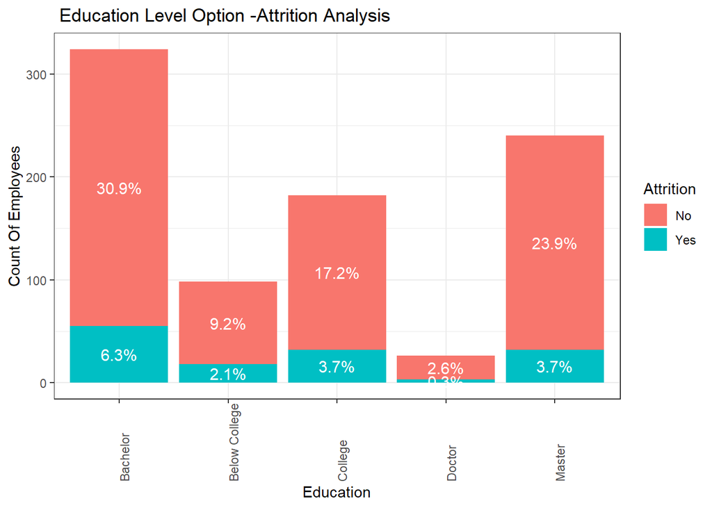

```r
dtEduc <- employeedata%>%
  dplyr::group_by(Education,Attrition)%>%
  dplyr::tally()%>%
  dplyr::mutate(percent=n/870)


 p15<-ggplot(data = dtEduc ,aes(x=Education, y = n,fill = Attrition))+ geom_bar(stat="identity")+geom_text(aes(label=paste0(sprintf("%1.1f", percent*100),"%")), position=position_stack(vjust=0.5), colour="white", size = 4)+theme(axis.text.x = element_text(angle = 90,hjust =0 ))+ggtitle(" Education Level Option -Attrition Analysis")+ylab("Count Of Employees")

 p15
```

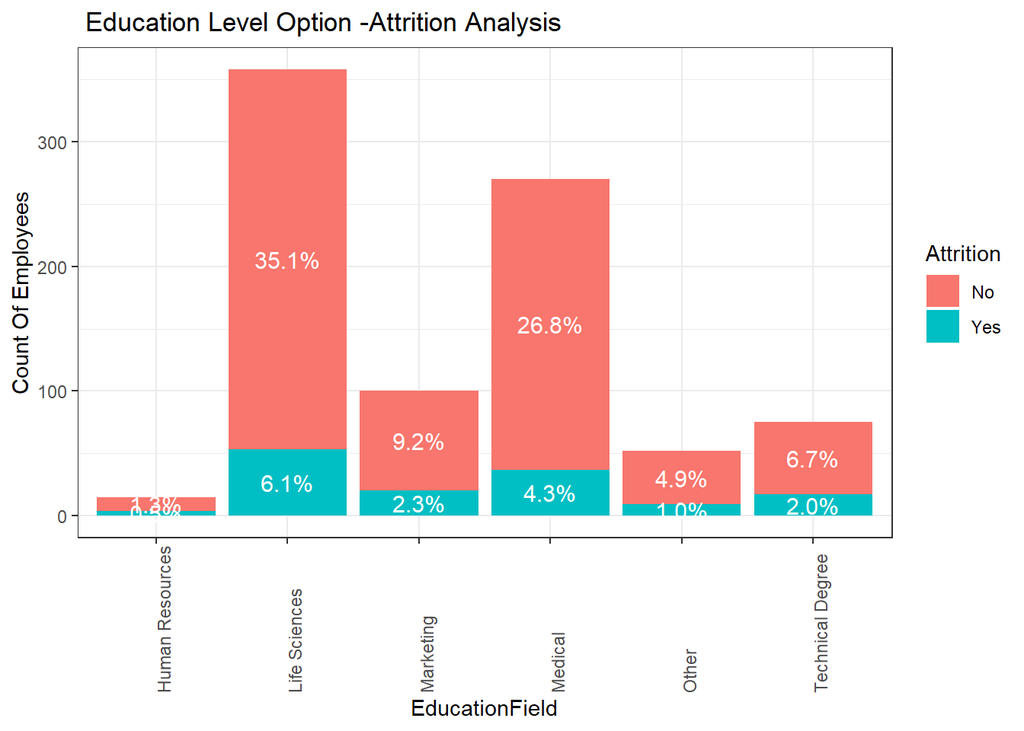

```r
dtEducField <- employeedata%>%
  dplyr::group_by(EducationField,Attrition)%>%
  dplyr::tally()%>%
  dplyr::mutate(percent=n/870)


 p16<-ggplot(data = dtEducField ,aes(x=EducationField, y = n,fill = Attrition))+ geom_bar(stat="identity")+geom_text(aes(label=paste0(sprintf("%1.1f", percent*100),"%")), position=position_stack(vjust=0.5), colour="white", size = 4)+theme(axis.text.x = element_text(angle = 90,hjust =0 ))+ggtitle(" Education Level Option -Attrition Analysis")+ylab("Count Of Employees")

 p16
```

## Employee Attrition vs YEarsAtCompany

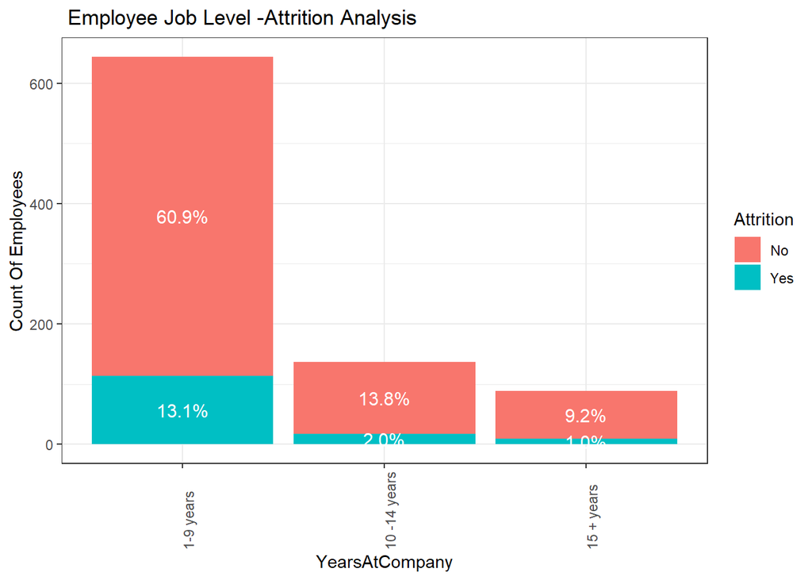

```r
dtYAtCompany <- employeedata%>%
  dplyr::group_by(YearsAtCompany,Attrition)%>%
  dplyr::tally()%>%
  dplyr::mutate(percent=n/870)


p17<- ggplot(data = dtYAtCompany,aes(x= YearsAtCompany, y = n,fill = Attrition))+ geom_bar(stat="identity")+geom_text(aes(label=paste0(sprintf("%1.1f", percent*100),"%")), position=position_stack(vjust=0.5), colour="white", size = 4)+theme(axis.text.x = element_text(angle = 90,hjust =0 ))+ggtitle(" Employee Job Level -Attrition Analysis")+ylab("Count Of Employees")

p17
```

## Employee Attrition vs “YearsSinceLastPromotion”

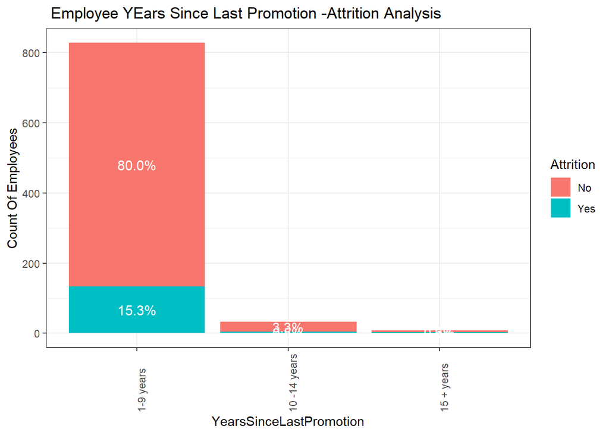

```r
dtPromo <- employeedata%>%
  dplyr::group_by(YearsSinceLastPromotion,Attrition)%>%
  dplyr::tally()%>%
  dplyr::mutate(percent=n/870)


p18<- ggplot(data = dtPromo ,aes(x= YearsSinceLastPromotion, y = n,fill = Attrition))+ geom_bar(stat="identity")+geom_text(aes(label=paste0(sprintf("%1.1f", percent*100),"%")), position=position_stack(vjust=0.5), colour="white", size = 4)+theme(axis.text.x = element_text(angle = 90,hjust =0 ))+ggtitle(" Employee YEars Since Last Promotion -Attrition Analysis")+ylab("Count Of Employees")

p18
```